# About Aerofit

#### Aerofit is a leading brand in the field of fitness equipment. Aerofit provides a product range including machines such as treadmills, exercise bikes, gym equipment, and fitness accessories to cater to the needs of all categories of people

# Business Problem

###### The company wants to know:

The market research team at AeroFit wants to identify the characteristics of the target audience for each type of treadmill offered by the company, to provide a better recommendation of the treadmills to the new customers. The team decides to investigate whether there are differences across the product with respect to customer characteristics.

Perform descriptive analytics to create a customer profile for each AeroFit treadmill product by developing appropriate tables and charts. For each AeroFit treadmill product, construct two-way contingency tables and compute all conditional and marginal probabilities along with their insights/impact on the business.

# Dataset

The company collected the data on individuals who purchased a treadmill from the AeroFit stores during the prior three months. The dataset has the following features:

Dataset link: https://d2beiqkhq929f0.cloudfront.net/public_assets/assets/000/001/125/original/aerofit_treadmill.csv?1639992749

# Column Profiling:

Product Purchased: KP281, KP481, or KP781 Age: In years Gender: Male/Female Education: In years MaritalStatus: Single or partnered Usage: The average number of times the customer plans to use the treadmill each week. Income: Annual income (in $) Fitness: Self-rated fitness on a 1-to-5 scale, where 1 is the poor shape and 5 is the excellent shape. Miles: The average number of miles the customer expects to walk/run each week

# Product Portfolio:

The KP281 is an entry-level treadmill that sells for $1,500. The KP481 is for mid-level runners that sell for $1,750. The KP781 treadmill is having advanced features that sell for $2,500.

# Concept Used:

###### Descriptive Statistics & Probability

```python
import pandas as pd
import numpy as np
import seaborn as sns
import matplotlib.pyplot as plt
```

```python
file_path = r'C:\Users\ADMIN\Downloads\data_sets\aerofit_treadmill_csv.txt'
df = pd.read_csv(file_path)
```

```python
df
```

|  | Product | Age | Gender | Education | MaritalStatus | Usage | Fitness | Income | Miles |
| --- | --- | --- | --- | --- | --- | --- | --- | --- | --- |
| 0 | KP281 | 18 | Male | 14 | Single | 3 | 4 | 29562 | 112 |
| 1 | KP281 | 19 | Male | 15 | Single | 2 | 3 | 31836 | 75 |
| 2 | KP281 | 19 | Female | 14 | Partnered | 4 | 3 | 30699 | 66 |
| 3 | KP281 | 19 | Male | 12 | Single | 3 | 3 | 32973 | 85 |
| 4 | KP281 | 20 | Male | 13 | Partnered | 4 | 2 | 35247 | 47 |
| ... | ... | ... | ... | ... | ... | ... | ... | ... | ... |
| 175 | KP781 | 40 | Male | 21 | Single | 6 | 5 | 83416 | 200 |
| 176 | KP781 | 42 | Male | 18 | Single | 5 | 4 | 89641 | 200 |
| 177 | KP781 | 45 | Male | 16 | Single | 5 | 5 | 90886 | 160 |
| 178 | KP781 | 47 | Male | 18 | Partnered | 4 | 5 | 104581 | 120 |
| 179 | KP781 | 48 | Male | 18 | Partnered | 4 | 5 | 95508 | 180 |

180 rows × 9 columns

```python
print("First 5 rows of the dataset:")
print(df.head())
```

```
First 5 rows of the dataset:
  Product  Age  Gender  Education MaritalStatus  Usage  Fitness  Income  Miles
0   KP281   18    Male         14        Single      3        4   29562    112
1   KP281   19    Male         15        Single      2        3   31836     75
2   KP281   19  Female         14     Partnered      4        3   30699     66
3   KP281   19    Male         12        Single      3        3   32973     85
4   KP281   20    Male         13     Partnered      4        2   35247     47
```

### Defining Problem Statement and Analysing basic metrics

Observations on shape of data, data types of all the attributes, conversion of categorical attributes to 'category' (If required), statistical summary

```python
print("information of the dataset:")
print(df.info())
```

```
information of the dataset:
<class 'pandas.core.frame.DataFrame'>
RangeIndex: 180 entries, 0 to 179
Data columns (total 9 columns):
 #   Column         Non-Null Count  Dtype
---  ------         --------------  -----
 0   Product        180 non-null    object
 1   Age            180 non-null    int64
 2   Gender         180 non-null    object
 3   Education      180 non-null    int64
 4   MaritalStatus  180 non-null    object
 5   Usage          180 non-null    int64
 6   Fitness        180 non-null    int64
 7   Income         180 non-null    int64
 8   Miles          180 non-null    int64
dtypes: int64(6), object(3)
memory usage: 12.8+ KB
None
```

```python
# Check the structure of the dataset (number of rows and columns)
print("\nDataset structure:")
print(df.shape)
```

```
Dataset structure:
(180, 9)
```

```python
# Check the data types of each column
print("\nData types of each column:")
print(df.dtypes)
```

```
Data types of each column:
Product          object
Age               int64
Gender           object
Education         int64
MaritalStatus    object
Usage             int64
Fitness           int64
Income            int64
Miles             int64
dtype: object
```

```python
# Get summary statistics for numerical columns
print("\nSummary statistics for numerical columns:")
print(df.describe())
```

```
Summary statistics for numerical columns:
              Age   Education       Usage     Fitness         Income  \
count  180.000000  180.000000  180.000000  180.000000     180.000000
mean    28.788889   15.572222    3.455556    3.311111   53719.577778
std      6.943498    1.617055    1.084797    0.958869   16506.684226
min     18.000000   12.000000    2.000000    1.000000   29562.000000
25%     24.000000   14.000000    3.000000    3.000000   44058.750000
50%     26.000000   16.000000    3.000000    3.000000   50596.500000
75%     33.000000   16.000000    4.000000    4.000000   58668.000000
max     50.000000   21.000000    7.000000    5.000000  104581.000000

            Miles
count  180.000000
mean   103.194444
std     51.863605
min     21.000000
25%     66.000000
50%     94.000000
75%    114.750000
max    360.000000
```

# Missing Value & Outlier Detection

```python
# Check for missing values in the dataset
print("\nMissing values in the dataset:")
print(df.isnull().sum())
```

```
Missing values in the dataset:
Product          0
Age              0
Gender           0
Education        0
MaritalStatus    0
Usage            0
Fitness          0
Income           0
Miles            0
dtype: int64
```

```python
# Check for duplicate rows in the dataset
print("\nDuplicate rows in the dataset:")
print(df.duplicated().sum())
```

```
Duplicate rows in the dataset:
0
```

##### Finding the outliers in the following columns

- Income
- Miles

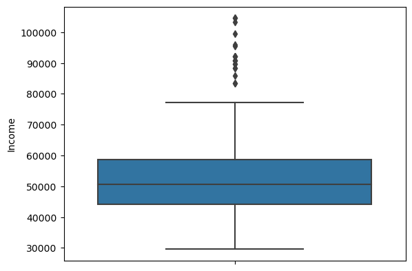

```python
# box plot
sns.boxplot(y= 'Income',data = df)
plt.show()
```

```python
# Insight : Above 80000 there are lot of ouliers
# Removing outliers from Income
df_V1 = df.copy()
q1 = df["Income"].quantile(.25)
q3 = df["Income"].quantile(.75)
iqr = q3-q1
df_V1 = df[(df["Income"] > q1 - 1.5*iqr )& (df["Income"] < q3 + 1.5*iqr)]
df_V1.shape
```

```
(161, 9)
```

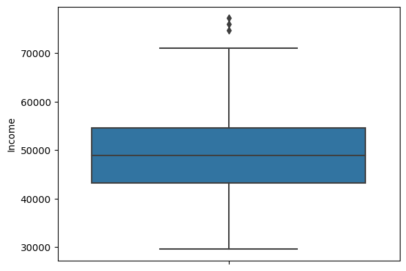

```python
sns.boxplot(y= 'Income',data = df_V1)
plt.show()
```

```python
print("Average_Income:",round(df_V1.Income.mean(),0))
print("Median_Income:",df_V1.Income.median())
```

```
Average_Income: 49119.0
Median_Income: 48891.0
```

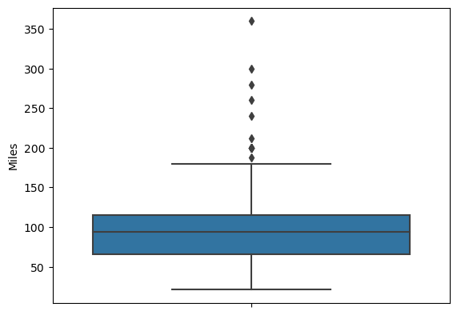

```python
sns.boxplot(y= 'Miles',data = df)
plt.show()
```

```python
# Insights: Above 180 Miles there are lot of outliers
# Removing the Outliers from Miles
df_V2 = df.copy()
q1 = df["Miles"].quantile(.25)
q3 = df["Miles"].quantile(.75)
iqr = q3-q1
df_V2 = df[(df["Miles"] > q1 - 1.5*iqr )& (df["Miles"] < q3 + 1.5*iqr)]
print(df_V2.shape)
print("Average_Miles:",round(df_V2.Miles.mean(),0))
print("Median_Miles:",df_V2.Miles.median())
```

```
(167, 9)
Average_Miles: 93.0
Median_Miles: 85.0
```

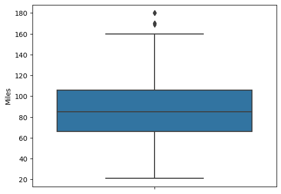

```python
sns.boxplot(y= 'Miles',data = df_V2)
plt.show()
```

##### Insights:

```python
# Adding new feature 'Age_Ranges'

df['Age_Ranges']=pd.cut(x=df['Age'],bins=[17, 29, 39, 50],labels=['18-29','30-39','40-50'])

#Adding new feature 'Age_Group_Names'

df['Age_Group_Names']=pd.cut(x=df['Age'], bins=[17, 29, 39, 50],labels=['Young Adult', 'Middle-aged Adult', 'Old-age Adult'])
```

```python
df
```

|  | Product | Age | Gender | Education | MaritalStatus | Usage | Fitness | Income | Miles | Age_Ranges | Age_Group_Names |
| --- | --- | --- | --- | --- | --- | --- | --- | --- | --- | --- | --- |
| 0 | KP281 | 18 | Male | 14 | Single | 3 | 4 | 29562 | 112 | 18-29 | Young Adult |
| 1 | KP281 | 19 | Male | 15 | Single | 2 | 3 | 31836 | 75 | 18-29 | Young Adult |
| 2 | KP281 | 19 | Female | 14 | Partnered | 4 | 3 | 30699 | 66 | 18-29 | Young Adult |
| 3 | KP281 | 19 | Male | 12 | Single | 3 | 3 | 32973 | 85 | 18-29 | Young Adult |
| 4 | KP281 | 20 | Male | 13 | Partnered | 4 | 2 | 35247 | 47 | 18-29 | Young Adult |
| ... | ... | ... | ... | ... | ... | ... | ... | ... | ... | ... | ... |
| 175 | KP781 | 40 | Male | 21 | Single | 6 | 5 | 83416 | 200 | 40-50 | Old-age Adult |
| 176 | KP781 | 42 | Male | 18 | Single | 5 | 4 | 89641 | 200 | 40-50 | Old-age Adult |
| 177 | KP781 | 45 | Male | 16 | Single | 5 | 5 | 90886 | 160 | 40-50 | Old-age Adult |
| 178 | KP781 | 47 | Male | 18 | Partnered | 4 | 5 | 104581 | 120 | 40-50 | Old-age Adult |
| 179 | KP781 | 48 | Male | 18 | Partnered | 4 | 5 | 95508 | 180 | 40-50 | Old-age Adult |

180 rows × 11 columns

###### Adding new categorical features based on income:

- Income_Group Classifying the income ranges based on below:
- Lower Income: 29000-50000 USD
- Middle Income: 50001-75000 USD
- Upper Income: 75001-10500 USD

```python
df['Income_Group'] = pd.cut(x = df['Income'], bins = [29000, 50000, 75000, 105000],labels = ['Lower Income', 'Middle Income', 'Upper Income'])
```

```python
df
```

|  | Product | Age | Gender | Education | MaritalStatus | Usage | Fitness | Income | Miles | Age_Ranges | Age_Group_Names | Income_Group |
| --- | --- | --- | --- | --- | --- | --- | --- | --- | --- | --- | --- | --- |
| 0 | KP281 | 18 | Male | 14 | Single | 3 | 4 | 29562 | 112 | 18-29 | Young Adult | Lower Income |
| 1 | KP281 | 19 | Male | 15 | Single | 2 | 3 | 31836 | 75 | 18-29 | Young Adult | Lower Income |
| 2 | KP281 | 19 | Female | 14 | Partnered | 4 | 3 | 30699 | 66 | 18-29 | Young Adult | Lower Income |
| 3 | KP281 | 19 | Male | 12 | Single | 3 | 3 | 32973 | 85 | 18-29 | Young Adult | Lower Income |
| 4 | KP281 | 20 | Male | 13 | Partnered | 4 | 2 | 35247 | 47 | 18-29 | Young Adult | Lower Income |
| ... | ... | ... | ... | ... | ... | ... | ... | ... | ... | ... | ... | ... |
| 175 | KP781 | 40 | Male | 21 | Single | 6 | 5 | 83416 | 200 | 40-50 | Old-age Adult | Upper Income |
| 176 | KP781 | 42 | Male | 18 | Single | 5 | 4 | 89641 | 200 | 40-50 | Old-age Adult | Upper Income |
| 177 | KP781 | 45 | Male | 16 | Single | 5 | 5 | 90886 | 160 | 40-50 | Old-age Adult | Upper Income |
| 178 | KP781 | 47 | Male | 18 | Partnered | 4 | 5 | 104581 | 120 | 40-50 | Old-age Adult | Upper Income |
| 179 | KP781 | 48 | Male | 18 | Partnered | 4 | 5 | 95508 | 180 | 40-50 | Old-age Adult | Upper Income |

180 rows × 12 columns

# Non-Graphical Analysis: Value counts and unique attributes

```python
for i in df.columns:
 print(i,':',df[i].nunique())
```

[output not shown]

```python
for i in df.columns:
 print(i,':',df[i].value_counts())
```

```
Product : Product
KP281    80
KP481    60
KP781    40
Name: count, dtype: int64
Age : Age
25    25
23    18
24    12
26    12
28     9
35     8
33     8
30     7
38     7
```

[output cut: 109 more lines]

# Observations:

1.There are no missing values in the data.

2.There are 3 unique products in the dataset.

3.KP281 is the most frequent product.

4.Minimum & Maximum age of the person is 18 & 50, mean is 28.79 and 75% of persons have age less than or equal to 33.

5.Most of the people are having 16 years of education i.e. 75% of persons are having education <= 16 years.

6.Out of 180 data points, 104's gender is Male and rest are the female.

7.Standard deviation for Income & Miles is very high. These variables might have the outliers in it.

# Visual Analysis - Univariate & Bivariate

###### For continuous variable(s): Distplot, countplot, histogram for univariate analysis

Understanding the distribution of the data for the Numerical(quantitative) attributes: Age Education Usage Fitness Income Miles

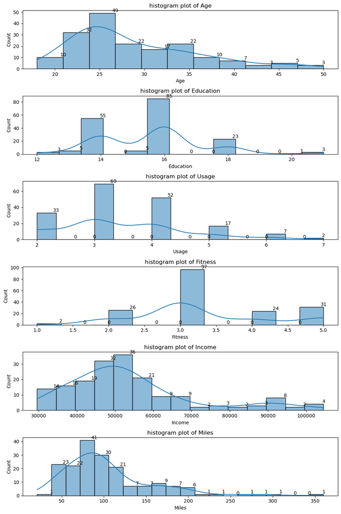

```python
# List of quantitative variables for countplot
Quant_distb = ['Age', 'Education', 'Usage', 'Fitness', 'Income', 'Miles']

# Set up the figure with subplots
fig, axes = plt.subplots(nrows=len(Quant_distb), ncols=1, figsize=(10, 15))

# Create count plots for each variable
for i, var in enumerate(Quant_distb):
    sns.histplot(x=var, data=df, ax=axes[i],kde=True)
    axes[i].set_title(f'histogram plot of {var}')

    # Annotate each bar with its count value
    for p in axes[i].patches:
        axes[i].annotate(format(p.get_height(), '.0f'),
                         (p.get_x() + p.get_width(), p.get_height()),
                         ha='center', va='center',
                         xytext=(0,5),  # Offset for text position
                         textcoords='offset points')

# Adjusting layout
plt.tight_layout()
plt.show()
```

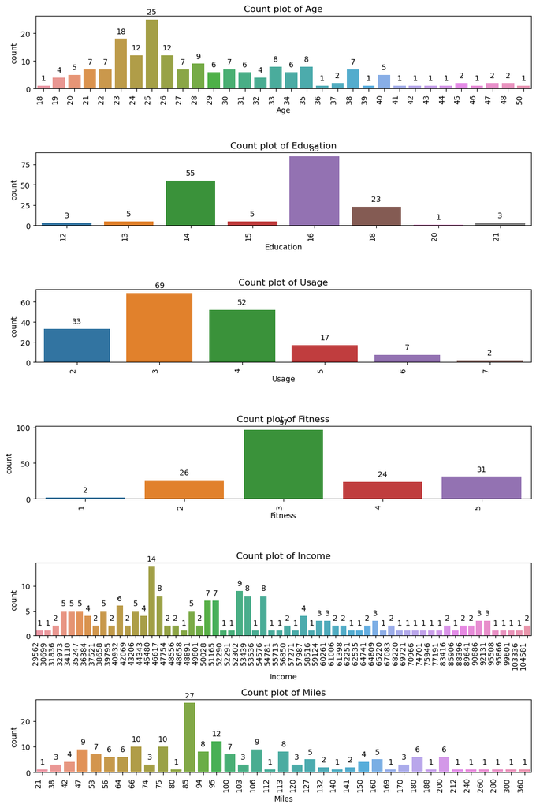

```python
# Setting up the figure with subplots
fig, axes = plt.subplots(nrows=len(Quant_distb), ncols=1, figsize=(10, 15))

# Create count plots for each variable
for i, var in enumerate(Quant_distb):
    sns.countplot(x=var, data=df, ax=axes[i])
    axes[i].set_title(f'Count plot of {var}')

    # Rotate x-axis labels by 90 degrees
    axes[i].set_xticklabels(axes[i].get_xticklabels(), rotation=90, ha='right')

    # Annotateting each bar with its count value
    for p in axes[i].patches:
        axes[i].annotate(format(p.get_height(), '.0f'),
                         (p.get_x() + p.get_width() / 2., p.get_height()),
                         ha='center', va='center',
                         xytext=(0, 10),  # Offset for text position
                         textcoords='offset points')

# Adjusting layout
plt.tight_layout()
plt.show()
```

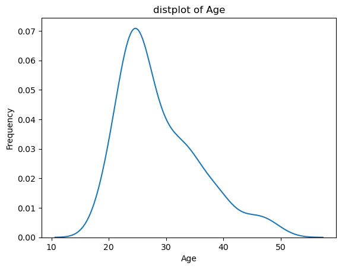

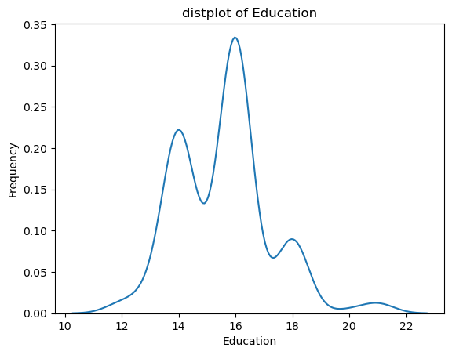

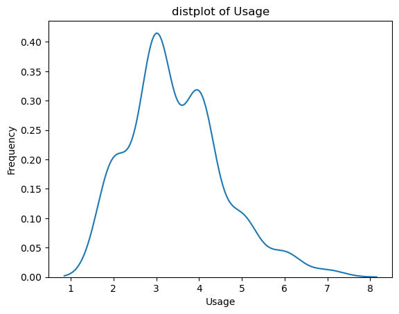

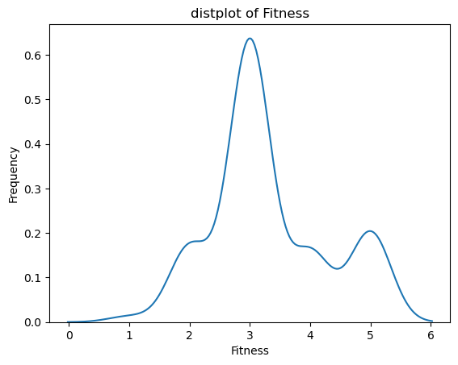

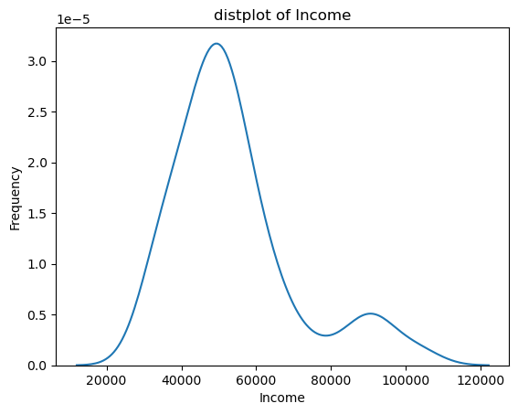

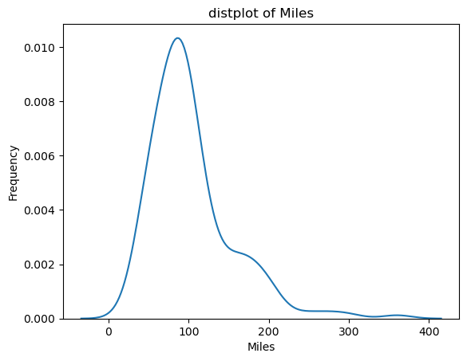

```python
for i in Quant_distb:
 sns.kdeplot(df[i])
 plt.xlabel(f"{i}")
 plt.ylabel('Frequency')
 plt.title(f'distplot of {i}')
 plt.show()
```

# observations

Education 14 & 16: Education levels of 14 and 16 appear to be more prevalent among the individuals in the dataset. This may indicate that a considerable number of individuals have completed education up to these levels.

Usage 3 & 4: There is a higher frequency of individuals with a usage level of 3 and 4. This suggests that the product or service being used is most commonly used at this level of frequency.

Fitness 3.0: Fitness level 3.0 seems to be more common among individuals in the dataset. This could imply that a majority of individuals fall into this fitness category.

Income 45000 to 55000: Individuals with income levels ranging from 45000 to 55000 appear to be more represented in the dataset. This income range may be characteristic of the target demographic or consumer base.

Miles 85 to 100: There is a higher occurrence of individuals who report running or covering distances between 85 to 100 miles. This range might be indicative of a typical distance covered by individuals using the product or service.

# For categorical variable(s): Boxplot

Understanding the distribution of the data for the categorical(qualitative) attributes: Product Gender MaritalStatus

[figure not shown]

[figure not shown]

```python
# Define the categorical variables for boxplot
Qual_distb = ['Product', 'Gender']

# Create boxplots for each categorical variable
for var in Qual_distb:
    plt.figure(figsize=(8, 6))
    sns.boxplot(x=var, y='Income', data=df)
    plt.title(f'Boxplot of Age by {var}')
    plt.xlabel(var)
    plt.ylabel('Age')
    plt.show()
```